# Water Pollution & Disease Analysis Report

Chimeruo Ugochi Egbo

June 26, 2026

## Data Overview

This report analyzes 3000 observations across 10 countries (Bangladesh, Brazil, China, Ethiopia, India, Indonesia, Mexico, Nigeria, Pakistan, USA) to evaluate water quality thresholds, treatment effectiveness, socio-economic resilience, environmental drivers, infant mortality predictors, and investment prioritization.

Sample of the water pollution & disease dataset

| Country | Region | Year | Water Source Type | Contaminant Level (ppm) | pH Level | Turbidity (NTU) | Dissolved Oxygen (mg/L) | Nitrate Level (mg/L) | Lead Concentration (µg/L) | Bacteria Count (CFU/mL) | Water Treatment Method | Access to Clean Water (% of Population) | Diarrheal Cases per 100,000 people | Cholera Cases per 100,000 people | Typhoid Cases per 100,000 people | Infant Mortality Rate (per 1,000 live births) | GDP per Capita (USD) | Healthcare Access Index (0-100) | Urbanization Rate (%) | Sanitation Coverage (% of Population) | Rainfall (mm per year) | Temperature (°C) | Population Density (people per km²) |
| --- | --- | --- | --- | --- | --- | --- | --- | --- | --- | --- | --- | --- | --- | --- | --- | --- | --- | --- | --- | --- | --- | --- | --- |
| Mexico | North | 2015 | Lake | 6.06 | 7.12 | 3.93 | 4.28 | 8.28 | 7.89 | 3344 | Filtration | 33.60 | 472 | 33 | 44 | 76.16 | 57057 | 96.92 | 84.61 | 63.23 | 2800 | 4.94 | 593 |
| Brazil | West | 2017 | Well | 5.24 | 7.84 | 4.79 | 3.86 | 15.74 | 14.68 | 2122 | Boiling | 89.54 | 122 | 27 | 8 | 77.30 | 17220 | 84.73 | 73.37 | 29.12 | 1572 | 16.93 | 234 |
| Indonesia | Central | 2022 | Pond | 0.24 | 6.43 | 0.79 | 3.42 | 36.67 | 9.96 | 2330 | None | 35.29 | 274 | 39 | 50 | 48.45 | 86022 | 58.37 | 72.86 | 93.56 | 2074 | 21.73 | 57 |
| Nigeria | East | 2016 | Well | 7.91 | 6.71 | 1.96 | 3.12 | 36.92 | 6.77 | 3779 | Boiling | 57.53 | 3 | 33 | 13 | 95.66 | 31166 | 39.07 | 71.07 | 94.25 | 937 | 3.79 | 555 |
| Mexico | South | 2005 | Well | 0.12 | 8.16 | 4.22 | 9.15 | 49.35 | 12.51 | 4182 | Filtration | 36.60 | 466 | 31 | 68 | 58.78 | 25661 | 23.03 | 55.55 | 69.23 | 2295 | 31.44 | 414 |
| Ethiopia | West | 2013 | Tap | 2.93 | 8.21 | 4.03 | 8.66 | 31.35 | 16.74 | 880 | None | 69.48 | 258 | 22 | 55 | 70.13 | 84334 | 53.45 | 86.11 | 51.11 | 2530 | 8.01 | 775 |
| China | East | 2022 | River | 0.06 | 6.11 | 3.12 | 6.97 | 44.98 | 1.23 | 2977 | Boiling | 55.43 | 208 | 23 | 90 | 92.59 | 6726 | 34.56 | 76.53 | 68.60 | 1573 | 22.42 | 584 |
| Mexico | Central | 2024 | Spring | 3.76 | 6.42 | 1.35 | 9.99 | 2.73 | 19.44 | 1172 | None | 44.17 | 397 | 0 | 10 | 67.30 | 76593 | 7.27 | 45.22 | 70.22 | 940 | 19.64 | 111 |

## 1. Water Quality Thresholds & Disease Outbreak Early Warning Systems

Mean disease incidence by contamination risk bin (relative risk vs. Low)

| Risk_Bin | Diarrheal_per_100k | Cholera_per_100k | Typhoid_per_100k | Total_per_100k | Total_Relative_Risk |
| --- | --- | --- | --- | --- | --- |
| Low | 248.8 | 24.0 | 49.4 | 322.2 | 1.00 |
| Medium | 249.1 | 24.3 | 48.7 | 322.1 | 1.00 |
| High | 251.4 | 24.5 | 49.7 | 325.7 | 1.01 |

Correlation of chemical/biological markers with total disease burden

| Chemical_Marker | Pearson_r | Spearman_rho |
| --- | --- | --- |
| Lead (µg/L) | 0.014 | 0.012 |
| Bacteria (CFU/mL) | 0.012 | 0.011 |
| Nitrate (mg/L) | -0.011 | -0.011 |
| Contaminant (ppm) | 0.004 | 0.004 |

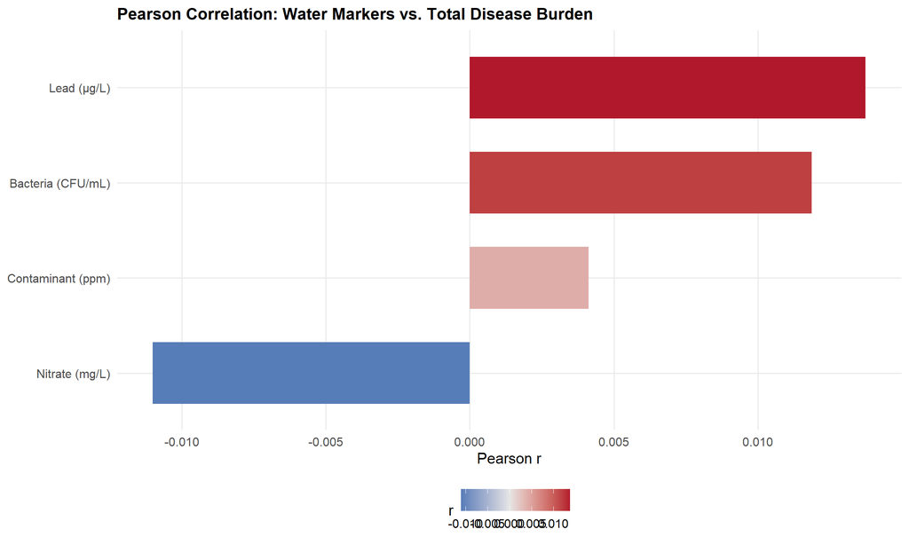

Linear regression: marker levels predicting total disease cases per 100,000

| Marker | Slope_cases_per_unit | p_value | R_squared |
| --- | --- | --- | --- |
| Lead (µg/L) | 0.35 | 0.452 | 2e-04 |
| Contaminant (ppm) | 0.21 | 0.822 | 0e+00 |
| Nitrate (mg/L) | -0.11 | 0.547 | 1e-04 |
| Bacteria (CFU/mL) | 0.00 | 0.516 | 1e-04 |

Logistic regression: odds of high disease outbreak (top tertile) per unit increase in marker

| Marker | Odds_Ratio_high_outbreak | p_value |
| --- | --- | --- |
| Contaminant (ppm) | 1.010 | 0.457 |
| Bacteria (CFU/mL) | 1.000 | 0.205 |
| Nitrate (mg/L) | 0.998 | 0.525 |
| Lead (µg/L) | 1.003 | 0.675 |

**Section 1 Insight:** Lead concentration shows the weakest-but-largest positive correlation with total disease burden in this dataset, though all marker correlations are near zero (|r| < 0.02), indicating disease rates are largely independent of single-marker thresholds here. Risk-bin segmentation shows minimal relative-risk escalation (High vs. Low ≈ 1.01×), suggesting composite indices should be validated against local outbreak data before deployment as early-warning triggers.